# 1 Installation

### 7.5 HBD segments

The HBD segments identified with the Viterbi algorithm are stored in the ..\@hbdseg, a data frame with one line per identified HBD segment and with nine columns accessed with the $ symbol:

- ..\@hbdseg$id is the number of the individual in which the HBD segments is located;
- ..\@hbdseg$chrom is the chromosome number of the HBD segments (this chromosome number refers to the position of the chromosome in the list of all chromosomes present in the input genotype data);
- ..\@hbdseg$start_snp is the number of the SNP at which the HBD segment starts (the SNP number within the chromosome);
- ..\@hbdseg$start_end is the number of the SNP at which the HBD segment ends (the SNP number within the chromosome);
- ..\@hbdseg$start_pos is the position at which the HBD segment starts (within the chromosome);
- ..\@hbdseg$start_end is the position at which the HBD segment ends (within the chromosome);
- ..\@hbdseg$number_snp is the number of consecutive SNPs in the HBD segment;
- ..\@hbdseg$length is the length of the HBD segment (for instance in bp or in cM/1000000);
- ..\@hbdseg$HBDclass is the HBD class associated with the HBD segment.

The table of HBD segments identified in the Belgian Blue cattle subset with the \texttt{mod3r} model is: \newline

```r
dim(bbb_mod3r@hbdseg)[1]
```

```
#> [1] 45
```

```r
head(bbb_mod3r@hbdseg[,1:8])
```

```
#>    id chrom start_snp end_snp start_pos   end_pos number_snp  length
#> 2   1     1         7      19    845494   2049400         13 1203907
#> 21  1     4       230     252 101677815 111368926         23 9691112
#> 1   1     6         1       9    202769   1014246          9  811478
#> 22  1     8       112     117  47179793  49524000          6 2344208
#> 23  1    10        47      50  13909586  14200836          4  291251
#> 24  1    11       204     210  94101466  95637394          7 1535929
```

There are 45 identified HBD segments (approximately 7 per individual). The first and second HBD segments are respectively 1.2 and 9.7 MB long and contain 13 and 23 SNPs. They belong both to the first individual and are located at the beginning of chromosome 1 and the end of chromosome 4.

To have summary statistics of length of HBD segments (in bp or in number of SNPs): \newline

```r
summary(bbb_mod3r@hbdseg$length)
```

```
#>     Min.  1st Qu.   Median     Mean  3rd Qu.     Max.
#>   291251  2782886  9000333 10866304 12141604 48659487
```

```r
summary(bbb_mod3r@hbdseg$number_snp)
```

```
#>    Min. 1st Qu.  Median    Mean 3rd Qu.    Max.
#>    4.00   16.00   23.00   30.47   34.00  145.00
```

The largest HBD segment is more than 48 Mb long, the average length is 10.87 Mb and the mean number of SNP per identified HBD segment is 30.47.

In the sheep population genotyped at higher density, the distribution of HBD segment presents some differences. \newline

```r
dim(soay_mix10r@hbdseg)[1]
```

```
#> [1] 14547
```

```r
head(soay_mix10r@hbdseg[,1:8])
```

```
#>    id chrom start_snp end_snp start_pos   end_pos number_snp  length
#> 2   1     1       314     369  15944770  18966270         56 3021501
#> 4   1     1       390     417  19945652  22120789         28 2175138
#> 6   1     1       755     906  40342997  48373831        152 8030835
#> 8   1     1       945     963  50614635  51923225         19 1308591
#> 10  1     1      1465    1512  80119112  82137439         48 2018328
#> 12  1     1      1969    2038 107797839 111474679         70 3676841
```

There are 14,547 identified HBD segments (approximately 132 per individual). The first and second HBD segments are respectively 3.0 and 2.2 MB long and contain 56 and 28 SNPs. They belong both to the first individual and are located on chromosome 1. The first individual has several segments on the first chromosome.

To obtain summary statistics of length of HBD segments (in bp or in number of SNPs): \newline

```r
summary(soay_mix10r@hbdseg$length)
```

```
#>     Min.  1st Qu.   Median     Mean  3rd Qu.     Max.
#>   116689  1756868  2811065  3790554  4620455 73719189
```

```r
summary(soay_mix10r@hbdseg$number_snp)
```

```
#>    Min. 1st Qu.  Median    Mean 3rd Qu.    Max.
#>    5.00   35.00   53.00   71.08   86.00 1402.00
```

The largest HBD segment is more than 73 Mb long, the average length is 3.79 Mb and the mean number of SNP per identified HBD segment is 71.08.

### 7.6 Accessor functions (easier access to slots)

We propose four accessor functions to interact more conveniently with the zres object, in particular with the most useful slots (..\@realized, ..\@hbdp and ..\@hbdseg).

#### 7.6.1 For realized autozygosity

To extract the table of realized autozygosity, you can use the function \texttt{realized} that takes as argument the name of the zres object and the numbers of the classes to be extracted (all by default). The function returns a data frame with one row per individual and one column per extracted classes. In addition, it gives names to the columns. For a pre-defined model, the names of HBD classes are “R_X” where X is the value of the corresponding \(R_k\) rate. For a model with rate estimation, the names of the HBD classes are “HBDclassX” where X is the number of the HBD class. For non-HBD classes, we use “NonHBD”. To extract the entire table for the results in BBB cattle with the mod3r model: \newline

```r
realized(bbb_mod3r)
```

```
#>           R_10        R_100    NonHBD
#> 1 0.0002451684 6.283497e-02 0.9369199
#> 2 0.0429870128 4.589439e-03 0.9524235
#> 3 0.0276528577 2.482290e-02 0.9475242
#> 4 0.0228609411 1.137513e-02 0.9657639
#> 5 0.0133014561 2.845040e-02 0.9582481
#> 6 0.1003679577 5.268664e-07 0.8996315
```

To extract the contribution of the first six HBD classes for the sheep analysis: \newline

```r
head(round(realized(soay_mix10r,seq(1,6)),5))
```

```
#>     R_2     R_4     R_8    R_16    R_32    R_64
#> 1 3e-05 0.05948 0.00000 0.00000 0.07063 0.11653
#> 2 0e+00 0.00000 0.00000 0.00006 0.08329 0.09915
#> 3 0e+00 0.00000 0.00000 0.00000 0.12816 0.10630
#> 4 1e-05 0.00003 0.00019 0.01993 0.09581 0.10143
#> 5 0e+00 0.00000 0.00000 0.01670 0.10734 0.09015
#> 6 0e+00 0.00000 0.00001 0.00044 0.16462 0.07180
```

#### 7.6.2 For inbreeding coefficients

To obtain the inbreeding coefficient \(F_{G-T}\) as the sum of contributions from all HBD classes with a \(R_k \leq T\), you can use the \texttt{cumhbd} function that takes as arguments the name of the zres object and the value of the threshold T (all HBD classes by default, when no threshold is specified).

To estimate the inbreeding coefficient in the sheep analysis by setting T equal to 100: \newline

```r
F100 <- cumhbd(soay_mix10r, 100)
summary(F100)
```

```
#>    Min. 1st Qu.  Median    Mean 3rd Qu.    Max.
#>  0.1805  0.2094  0.2228  0.2228  0.2369  0.2812
```

To estimate the inbreeding coefficient in the BBB cattle data and the analysis with the mod3r model including either the first HBD class or both of them: \newline

```r
F10 <- cumhbd(bbb_mod3r, 10)
F100 <- cumhbd(bbb_mod3r, 100)
cbind(F10,F100)
```

```
#>               F10       F100
#> [1,] 0.0002451684 0.06308014
#> [2,] 0.0429870128 0.04757645
#> [3,] 0.0276528577 0.05247576
#> [4,] 0.0228609411 0.03423607
#> [5,] 0.0133014561 0.04175186
#> [6,] 0.1003679577 0.10036848
```

To estimate the inbreeding coefficient in the BBB cattle data but for the analysis performed with the 1 HBD class model. Computations are performed with respect to three values for T (20, 50 and 100) and with an estimated rate \(R_1\) for each individual: \newline

```r
F20 <- cumhbd(bbb_results3, 20)
```

```
#> [1] "cumhbd is not recommended for a model with different rates per individual!"
```

```r
F50 <- cumhbd(bbb_results3, 50)
```

```
#> [1] "cumhbd is not recommended for a model with different rates per individual!"
```

```r
F100 <- cumhbd(bbb_results3, 100)
```

```
#> [1] "cumhbd is not recommended for a model with different rates per individual!"
```

```r
cbind(F20,F50,F100,bbb_results3@krates[,1])
```

```
#>             F20        F50       F100
#> [1,] 0.00000000 0.00000000 0.05852398 73.280
#> [2,] 0.04253227 0.04253227 0.04253227  6.218
#> [3,] 0.00000000 0.04469971 0.04469971 24.439
#> [4,] 0.00000000 0.03333425 0.03333425 24.021
#> [5,] 0.00000000 0.03563496 0.03563496 35.496
#> [6,] 0.10070006 0.10070006 0.10070006 10.420
```

We first observe that the function does not recommend to estimate an inbreeding coefficient when the \(R_k\) rates are estimated. This is because in that situation, each individual has different HBD classes and then the number of classes included in the estimation would vary according to the individuals. Here, only individuals 2 and 6 have a non-zero inbreeding coefficient when setting T equal to 20. All individuals have a non-zero inbreeding coefficient with T equals to 50 with the exception of the first individual. Finally, all the estimated autozygosity is considered when T equals 100.

#### 7.6.3 For HBD segments

The \texttt{rohbd} function can help to extract all HBD segments for a group of individuals and a genomic region. By default HBD segments for all individuals and the entire genome are extracted. The individuals are specified by ids = x where x is a vector with the individual numbers. The region is specified by chrom = y where y is the chromosome number. The coordinates can also be specified with the startPos and endPos arguments (these are not used if the chrom is NULL).

To extract all HBD segments identified in the sheep population overlapping the region from 10 to 20 Mb on chromosome 25. \newline

```r
roh25_10_20 <- rohbd(zres = soay_mix10r, chrom = 25,
                     startPos= 10000000,endPos = 20000000, inside = FALSE)
dim(roh25_10_20)
```

```
#> [1] 84  9
```

```r
head(roh25_10_20[,1:8])
```

```
#>      id chrom start_snp end_snp start_pos  end_pos number_snp   length
#> 4171  2    25       159     237   9657834 13809614         79  4151781
#> 616   2    25       272     338  15416899 18657658         67  3240760
#> 4183  5    25       280     409  15856692 21919108        130  6062417
#> 2272  7    25       318     409  17689768 21919108         92  4229341
#> 618   9    25       299     352  16816914 19159330         54  2342417
#> 337  10    25       267     488  15231602 26224691        222 10993090
```

```r
summary(roh25_10_20$length)
```

```
#>     Min.  1st Qu.   Median     Mean  3rd Qu.     Max.
#>  1005736  2423824  3489860  4809936  6062417 24322495
```

There are 84 HBD segments overlapping the region, with a mean length of 4.8 Mb and the longest segments is more than 24 Mb. If we restrict the extraction on HBD segments inside the region: \newline

```r
roh25_10_20 <- rohbd(zres = soay_mix10r, chrom = 25,
                     startPos= 10000000,endPos = 20000000, inside = TRUE)
dim(roh25_10_20)
```

```
#> [1] 43  9
```

```r
head(roh25_10_20[,1:8])
```

```
#>       id chrom start_snp end_snp start_pos  end_pos number_snp  length
#> 616    2    25       272     338  15416899 18657658         67 3240760
#> 618    9    25       299     352  16816914 19159330         54 2342417
#> 4218  11    25       270     365  15326949 19823535         96 4496587
#> 4195  12    25       303     362  17029368 19655167         60 2625800
#> 41612 13    25       272     326  15416899 17997283         55 2580385
#> 22413 14    25       218     237  12792777 13809614         20 1016838
```

```r
summary(roh25_10_20$length)
```

```
#>    Min. 1st Qu.  Median    Mean 3rd Qu.    Max.
#> 1005736 2278147 2446597 2651727 3173355 4755436
```

```r
roh25_10_20 <- rohbd(zres = soay_mix10r, ids = c(15,56,97,103,108))
dim(roh25_10_20)
```

```
#> [1] 676   9
```

```r
head(roh25_10_20[,1:8])
```

```
#>      id chrom start_snp end_snp start_pos   end_pos number_snp   length
#> 2180 15     1       228     262  11540961  13301343         35  1760383
#> 4100 15     1       324     403  16471993  21164217         80  4692225
#> 690  15     1      1260    1385  68918632  76227410        126  7308779
#> 890  15     1      2241    2459 124296584 137186574        219 12889991
#> 1080 15     1      2467    2511 137752062 139783950         45  2031889
#> 1268 15     1      3078    3163 171842250 176779276         86  4937027
```

#### 7.6.4 For local HBD probabilities (locus specific)

The \texttt{probhbd} function help to extract the local HBD probabilities for one individual in a specific region. HBD probabilities represent large amount of data. Therefore, we extract only a total HBD probability by summing over all HBD classes. As for the inbreeding coefficient, the user can specify a threshold T to determine which HBD classes should be used in the sum and considered as autozygous (all by default).

The function takes as arguments the \texttt{zres} object but also the \texttt{zooin} object (that contains some information on the markers, their position and the chromosome number). The individual is indicated with the id = . argument. The same arguments as for the \texttt{rohbd} function are used to declare the genomic region (chrom, startPos, endPos). By default all positions are extracted.

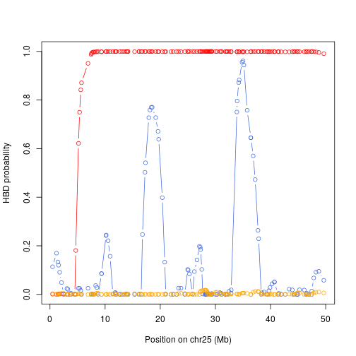

```r
y6 <- probhbd(zres = bbb_mod3r, zooin = bbb, id = 6, chrom = 19,
              startPos = 0, endPos = 50000000)
x <- bbb@bp[bbb@chrbound[19,1]:bbb@chrbound[19,2]]
x <- x[x >=0 & x<= 50000000]/1000000
plot(y6~x,type='b',ylim=c(0,1),ylab='HBD probability',col='red',
     xlab='Position on chr25 (Mb)')
y1 <- probhbd(zres = bbb_mod3r, zooin = bbb, id = 1, chrom = 19,
              startPos = 0, endPos = 50000000)
y2 <- probhbd(zres = bbb_mod3r, zooin = bbb, id = 2, chrom = 19,
              startPos = 0, endPos = 50000000)
par(new=TRUE)
plot(y1~x,type='b',ylim=c(0,1),ylab='',col='royalblue',xlab='',axes=FALSE)
par(new=TRUE)
plot(y2~x,type='b',ylim=c(0,1),ylab='',col='orange',xlab='',axes=FALSE)
```

We observe that individual 6 has a long HBD segment, whereas there is no evidence of HBD segments in individual 2. For the first individual, we see two small regions were the HBD probabilities reach approximately 0.80 and 0.95. These probabilities suggest presence of HBD segment that would not have been captured with window-based approaches because they contain too few markers.

The use of the threshold T determines which classes are included. In the previous example, we used two HBD classes. By setting T = 20, we would use only one HBD class with \(R_k = 10\) (and not the class with \(R_k = 100\)): \newline

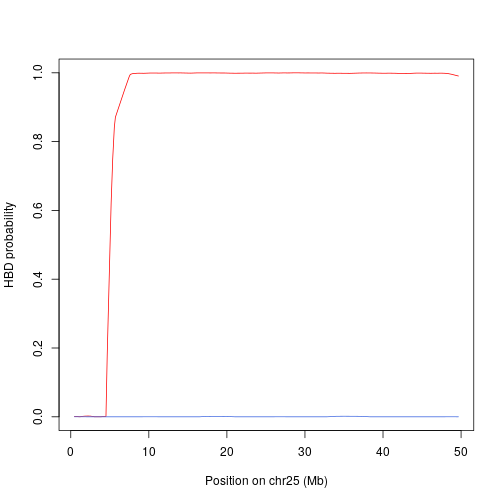

```r
y6b <- probhbd(zres = bbb_mod3r, zooin = bbb, id = 6, chrom = 19,
              startPos = 0, endPos = 50000000,T=20)
y1b <- probhbd(zres = bbb_mod3r, zooin = bbb, id = 1, chrom = 19,
              startPos = 0, endPos = 50000000,T=20)
plot(y6b~x,type='l',ylim=c(0,1),ylab='HBD probability',col='red',
     xlab='Position on chr25 (Mb)')
par(new=TRUE)
plot(y1b~x,type='l',ylim=c(0,1),ylab='',col='royal blue',xlab='',axes=FALSE)
```

The curve is almost identical for individual 6 because the long HBD segment is associated to the first HBD class (rate \(R_k = 10\)). The HBD probabilities for the first individual are now equal to 0, because the evidence for short segments previously observed is associated with the second HBD class, with a higher rate (100) corresponding to shorter segments.

### 7.6.5 Combining accessor functions with standard summary functions

To obtain a summary of the realized inbreeding: \newline

```r
summary(realized(soay_mix10r))
```

```
#>       R_2                 R_4                 R_8
#>  Min.   :0.000e+00   Min.   :0.000e+00   Min.   :0.000e+00
#>  1st Qu.:0.000e+00   1st Qu.:0.000e+00   1st Qu.:1.000e-08
#>  Median :3.300e-09   Median :3.000e-08   Median :5.900e-07
#>  Mean   :4.285e-06   Mean   :1.891e-03   Mean   :3.310e-03
#>  3rd Qu.:1.038e-07   3rd Qu.:1.020e-06   3rd Qu.:5.146e-05
#>  Max.   :3.629e-04   Max.   :7.638e-02   Max.   :5.862e-02
#>       R_16                R_32              R_64
#>  Min.   :0.000e+00   Min.   :0.00000   Min.   :0.02755
#>  1st Qu.:2.850e-06   1st Qu.:0.07032   1st Qu.:0.09041
#>  Median :1.397e-04   Median :0.09563   Median :0.10679
#>  Mean   :1.788e-02   Mean   :0.09288   Mean   :0.10678
#>  3rd Qu.:3.308e-02   3rd Qu.:0.11857   3rd Qu.:0.12660
#>  Max.   :9.016e-02   Max.   :0.17277   Max.   :0.16842
#>      R_128               R_256               R_512
#>  Min.   :0.000e+00   Min.   :0.000e+00   Min.   :0.000e+00
#>  1st Qu.:6.200e-08   1st Qu.:4.410e-11   1st Qu.:1.810e-12
#>  Median :5.610e-07   Median :1.195e-09   Median :9.956e-11
#>  Mean   :1.353e-04   Mean   :8.266e-08   Mean   :1.121e-08
#>  3rd Qu.:3.198e-06   3rd Qu.:3.407e-08   3rd Qu.:4.397e-09
#>  Max.   :1.414e-02   Max.   :2.387e-06   Max.   :2.762e-07
#>      NonHBD
#>  Min.   :0.7188
#>  1st Qu.:0.7631
#>  Median :0.7772
#>  Mean   :0.7771
#>  3rd Qu.:0.7906
#>  Max.   :0.8195
```

Similarly, for inbreeding coefficients with T equal to 100: \newline

```r
summary(cumhbd(soay_mix10r,100))
```

```
#>    Min. 1st Qu.  Median    Mean 3rd Qu.    Max.
#>  0.1805  0.2094  0.2228  0.2228  0.2369  0.2812
```

The \texttt{summary} function can also be used with the \texttt{hbdseg} data.frame (for the entire frame or for some variables). We can also use a function to plot an histogram of length of HBD segments: \newline

```r
allseg <- rohbd(zres = soay_mix10r)
summary(allseg$length)
```

```
#>     Min.  1st Qu.   Median     Mean  3rd Qu.     Max.
#>   116689  1756868  2811065  3790554  4620455 73719189
```

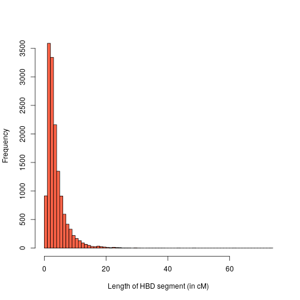

```r
hist(allseg$length/1000000,xlab="Length of HBD segment (in cM)",main="",col='tomato',nc=100)
```

Alternatively, we provide plot functions to obtain an overview of the results and visualize them.

### 7.7 Information for DoRIS

DoRIS is a software [@palamara2012] that use IBD segments to infer past demographic history in populations. To that end, it uses the number of IBD segments observed in 1Mb bins (over a range of values). The distribution can help to infer past effective population size. The software works either with counts, either with proportion of the genome in different bins (“sharing”). HBD segments are a special case of IBD segments. With IBD segments, the number of pair of haplotypes compared is large that with HBD segments (equal to the number of individuals) but with HBD segments there is no need to phase the data. If the sample is large enough and autozygous segments are frequent, HBD segments can be used for the application.

The \texttt{zoodoris} function allows to generate tables for DoRIS either as counts (\texttt{method = “counts”}) or as proportion of the genome (\texttt{method = “sharing”}). The function works on a \texttt{zres} object and need the range of HBD segments that are used (\texttt{minv} and \texttt{maxv} are the minimal and maximal length considered, in cM). Finally, the user must also provide the length of the genome in cM (using only autosomes where HBD segments have been searched for) with the \texttt{glen} argument.

```r
zoodoris(zres = wilt_mix10r, minv = 5, maxv = 10, glen = 2450, method = "counts")
```

```
#>   win_st win_end nseg
#> 1      5       6  148
#> 2      6       7  117
#> 3      7       8  104
#> 4      8       9   88
#> 5      9      10   67
```

To obtain proportion of the genome in the bins: \newline

```r
zoodoris(zres = wilt_mix10r, minv = 5, maxv = 10, glen = 2450, method = "sharing")
```

```
#>   win_st win_end    sharing
#> 1      5       6 0.01445879
#> 2      6       7 0.01357026
#> 3      7       8 0.01384652
#> 4      8       9 0.01326850
#> 5      9      10 0.01129579
```

We can compare the distribution for three different sheep populations: \newline

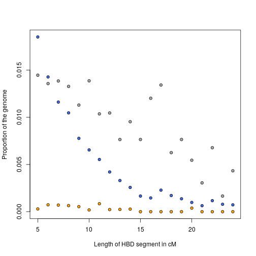

```r
dtw <- zoodoris(zres = wilt_mix10r, minv = 5, maxv = 25, glen = 2450, method = "sharing")
dts <- zoodoris(zres = soay_mix10r, minv = 5, maxv = 25, glen = 2450, method = "sharing")
dtr <- zoodoris(zres = rara_mix10r, minv = 5, maxv = 25, glen = 2450, method = "sharing")
matplot(dtw$win_st,cbind(dtw$sharing,dts$sharing,dtr$sharing),
        xlab = 'Length of HBD segment in cM', ylab = 'Proportion of the genome',
        type ='p', pch=c(21,21,21),bg=c('dark grey','royal blue','orange'),
        col=c('black','black','black'))
```

Clear differences are observed, with the Rasa Aragonesa individuals (orange) having few HBD segments in all bins, the Soay individuals (blue) having a high number of the shortest segments and the Wiltshire individuals (grey) presenting also large values for long HBD segments.

## 8 Plotting

Four plotting functions are helpful to interpret the results. They plot either the partitioning of the genome in HBD class at the population or the individual level, the contribution of different classes to the genome or HBD segments. We recommend to use the functions representing proportion of the genome in different HBD classes or partitioning of the genome in HBD classes **only with models with pre-defined rates** (see section 5).

### 8.1. Proportion of the genome associated with different HBD classes (population)

The \texttt{zooplot_prophbd} represents the proportion of the genome associated with the different HBD classes at the population level. The input is a named list of zres object (list(name1 = zres1, name2 = zres2, …)). The list can contain one or several populations. When provided, the names are used in the plot. Three format can be used with the \texttt{style} arguments: “barplot”, “lines” and “boxplot” (boxplot can only be use with a single zres object).

To plot a single population with boxplots: \newline

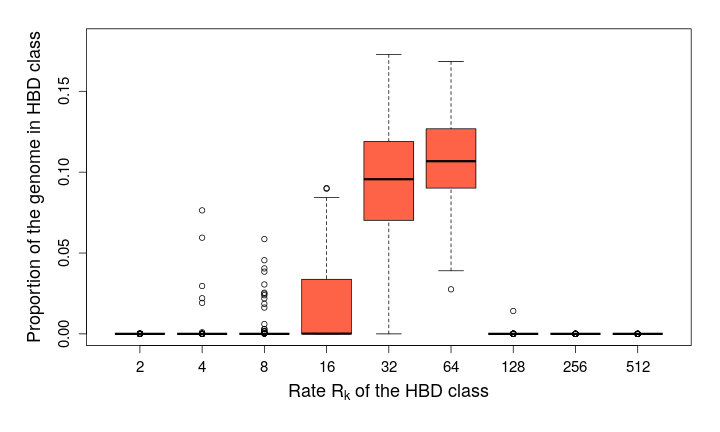

```r
zooplot_prophbd(list(Soay = soay_mix10r), cols = 'tomato', style = 'boxplot')
```

To plot three populations with barplots: \newline

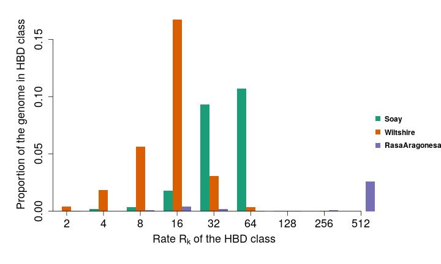

```r
zooplot_prophbd(list(Soay=soay_mix10r,Wiltshire=wilt_mix10r,
                     RasaAragonesa=rara_mix10r),style='barplot')
```

The plot can also represents cumulative proportions: the fraction of the genome in all HBD classes with rates \(R_k \leq T\). For the plot, we use the rate of the HBD classes as values for T. So, we obtain the fraction of the genome in the first HBD class, the two first HBD classes, the first three HBD classes, etc. These values can be interpreted as inbreeding coefficients estimated with respect to different base populations (see sections 2.4, 7.3, 7.5.2 or @DG2017 and @sole2017 for more details).

To plot the average inbreeding coefficients (cumulative values) for three populations with lines: \newline

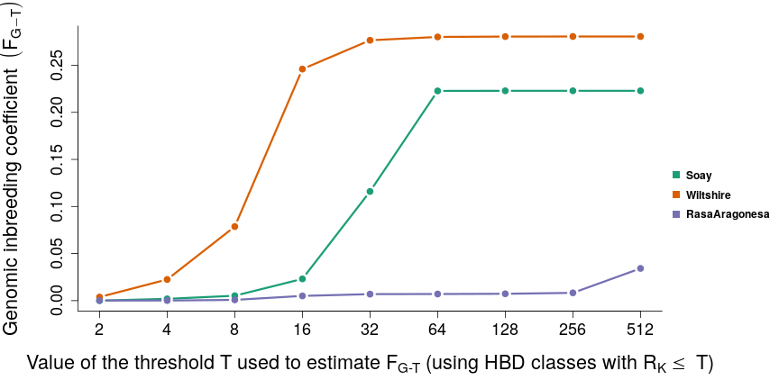

```r
zooplot_prophbd(list(Soay=soay_mix10r,Wiltshire=wilt_mix10r,
                     RasaAragonesa=rara_mix10r),style='lines', cumulative = TRUE)
```

### 8.2. Proportion of the genome associated with different HBD classes (individuals)

The \texttt{zooplot_individuals} function represents the same results as the \texttt{zooplot_prophbd} function but at an individual level. Each individual is represented by a line (no barplots or boxplots). The function plots either the proportion of the genome in different HBD classes or cumulative proportions (see above) if \texttt{cumulative} is set to \texttt{TRUE}. The average value of the population is added in red. As before, the input is a named list of zres object (list(name1 = zres1, name2 = zres2, …)). The list can contain one or several populations. When provided, the population names are used in the plot. The \texttt{ncols} argument determines the number of graphs (populations) plotted next to each other. \newline

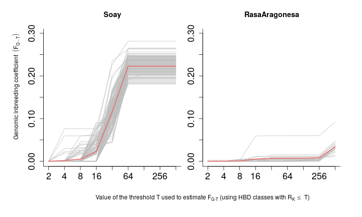

```r
pop2 <- list(Soay=soay_mix10r,RasaAragonesa=rara_mix10r)
zooplot_individuals(pop2, cumulative = TRUE)
```

We observe than Soay sheep present higher levels of autozygosity and that patterns are relatively homogeneous in both populations.

### 8.3. Partitioning individual genomes in different HBD classes

The \texttt{zooplot_partitioning} function represents for each individual the proportion of the genome in each HBD class. Each individual is represent as a stacked barplot. The total height represents the total autozygosity level. The contribution of each HBD class (in \% of the genome) is represented as a bar of a different color (black, brown, red for the most recent HBD classes).

The input is again a named list of zres object (list(name1 = zres1, name2 = zres2, …)). The list can contain one or several populations. When provided, the population names are used in the plot. The user can provide the colors of the bars (argument \texttt{cols}), can choice to plots the ids or not (argument \texttt{plotids}), can give a list of individuals to plot (argument \texttt{toplot}, a list of vectors containing the individuals to plot for each population), can choose to plot a random sample of individuals (argument \texttt{randomids} set to TRUE with \texttt{nrandom} a vector containing the number of individuals to select for each population and \texttt{seed} being the random seed). The \texttt{ylim} argument indicates the minimal and maximal values of the y-axis, the \texttt{border} argument indicates whether a border is drawn around each bar, the \texttt{nonhbd} argument indicates whether a border is drawn around the non-hbd contribution and the \texttt{vertical} argument specifies if sample names are written vertically or not. To plot the partitioning in the Wiltshire population: \newline

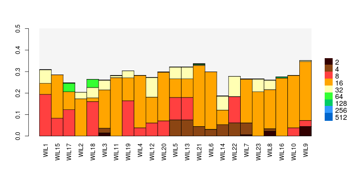

```r
zooplot_partitioning(list(Wiltshire=wilt_mix10r), ylim = c(0,0.5), nonhbd = FALSE)
```

Next we plot the three sheep population. To reduce the number of individuals, we select randomly 20 individuals per population and we don't print the ids. \newline

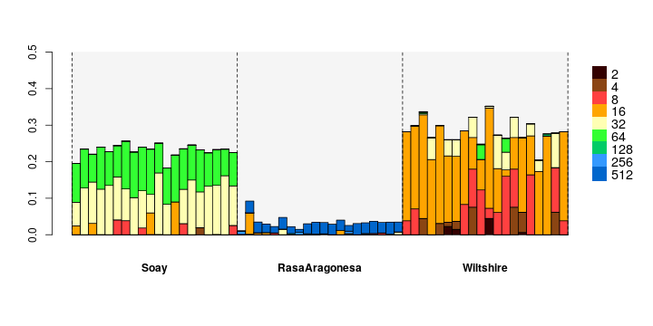

```r
pop3 <- list(Soay=soay_mix10r,RasaAragonesa=rara_mix10r,Wiltshire=wilt_mix10r)
zooplot_partitioning(pop3, randomids = TRUE, nrandom = c(20,20,20), plotids = FALSE,
                     ylim=c(0,0.5), nonhbd = FALSE)
```

Soay and Wiltshire populations present higher levels of autozygosity. The Wiltshire individuals present more recent autozygosity (brown, red, orange bars) compared to the Soay individuals where light yellow (\(R_k = 32\)) and green (\(R_k = 64\)) dominate, indicating that the Wiltshire individual have more recent common ancestors causing autozygosity.

### 8.4. Plotting identified HBD segments

The \texttt{zooplot_hbdseg} function plots the identified segments for a selected region. The region is specified with the \texttt{chr} and \texttt{coord} arguments. A minimal segment size can be selected with the \texttt{minlen} arguments.

Some arguments are identical to the \texttt{zooplot_partitioning function}: those to select individuals, \texttt{randomids}, \texttt{nrandom}, \texttt{seed}, \texttt{toplot}, \texttt{plotids}. The \texttt{cols} argument allows to specify the color used for each population or zres object in the input list.

```
#> random seed  100  is used to sample ids
```

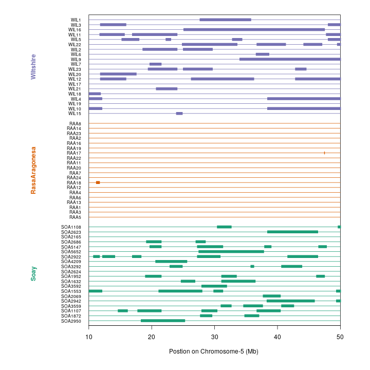

[figure not shown]

```r
zooplot_hbdseg(pop3, randomids = TRUE, nrandom = c(20,20,20),
               chr=5,coord=c(10000000,50000000))
```

## 9 Impact of data informativity

With genotyping data, the HBD segments are accurately identified with 50 or 100 SNPs per segments (as for window-based RoH) and with 20 SNPs per segment the method is still efficient but in that case, false positive and false negative rates are higher and the use of HBD probabilities is recommended (it is risky to use window-based RoH with only 20 SNPs per window). If we use sequencing data, we observe that with low cover, the number of marker per HBD segments must be increased to obtain similar accuracy.

We can observe that genotyping error rates have a small impact because they are accounted for in the model. Still, with higher error rate (0.01) we observe that the number of false positive HBD segments increases because heterozygous genotypes are less penalized, the model allows approximately one heterozygous SNP per 100 SNPs (the accuracy in HBD segments remains however unchanged). Similarly, when the overall autozygosity is higher the risk of false positive HBD segments increases because since HBD segments are more frequent, the probability to observe HBD segments is higher. In that case, we also observe that the power to identify the HBD segments increases in parallel.

Regarding the genome-wide autozygosity level, its association with the number of SNPs per HBD segment is more complex as it also depends the total number of SNPs.

## 10 References